# Survival

F.A. Barrios

2022-04-15

```r
library(tidyverse)
library(car)
library(survival)
library(survminer)
library(coin)
library(partykit)
```

## Survival data

Survival data, or time-to-event data, are measurements of elapsed time between the beginning of a study (enrollment of subject participation) and the final disposition of the subject. This elapsed time could be represented by the point in time when the subject enters the study and the final time of participation. Survival in this context simply means that an event has not occurred, not, necessarily, that the endpoint of interest involved an examination of “life” and “death.”

### Patients treated with Radioimmunotherapy Examples from HSAUR

In a clinical trial investigating a novel radioimmunotherapy treatment, the question was if under the radioimmunotherapy the malignant glioma patients survive longer. The overall survival, i.e., the time from the beginning of the therapy to the disease-caused death of the patient, is compared for two groups. A control group underwent standard therapy and a second group of patients was treated in addition with radioimmunotherapy, the survival time was compared for the two groups of patients. To assess if the survival times were different we plot the Kaplan-Meier estimates stratified for the group of patients from grades III and IV and perform a log-rank test. Function logrank_test from package `coin` can be used to compute an exact conditional test answering the question whether the survival times differ for grade III patients (`g3`). For all possible permutations of the groups on the censored response variable, the test statistic is computed and the fraction of whose being greater than the observed statistic defines the exact p-value. And the same exercise can be performed for patients with grade IV glioblastoma (GBM, `g4`).

```r
# Examples Chp 11 HSAUR
head(glioma)
```

```
  no. age    sex histology group event time
1   1  41 Female    Grade3   RIT  TRUE   53
2   2  45 Female    Grade3   RIT FALSE   28
3   3  48   Male    Grade3   RIT FALSE   69
4   4  54   Male    Grade3   RIT FALSE   58
5   5  40 Female    Grade3   RIT FALSE   54
6   6  31   Male    Grade3   RIT  TRUE   25
```

```r
tail(glioma)
```

```
   no. age    sex histology   group event time
32  13  57 Female       GBM Control  TRUE    8
33  14  71 Female       GBM Control  TRUE    8
34  15  61   Male       GBM Control  TRUE    6
35  16  65   Male       GBM Control  TRUE   14
36  17  50   Male       GBM Control  TRUE   13
37  18  42 Female       GBM Control  TRUE   25
```

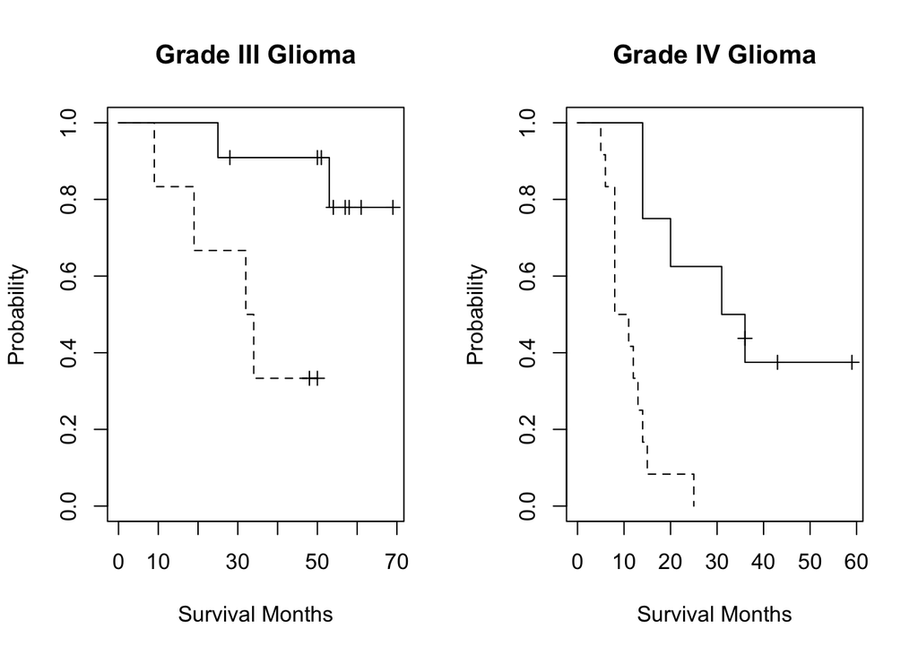

```r
# the data division in tumor grade
g3 <- subset(glioma, histology == "Grade3")
g4 <- subset(glioma, histology == "GBM")
#
layout(matrix(1:2, ncol=2))

plot(survfit(Surv(time, event) ~ group, data = g3), main = "Grade III Glioma", lty = c(2,1), mark.time = TRUE, ylab = "Probability", xlab = "Survival Months")
plot(survfit(Surv(time, event) ~ group, data = g4), main = "Grade IV Glioma", lty = c(2,1), mark.time = TRUE, ylab = "Probability", xlab = "Survival Months")
```

To assess if the malignant glioma patients treated with the radioimmunotheraoy survive longer as the Kaplan-Meier plots suggest, first we can perform a log-rank test, `survdiff` from the `survive` R package.

```r
# to assess if there are different survival we can perform a log-rank test from survival
survdiff(Surv(time, event) ~ group, data = g3)
```

```
Call:
survdiff(formula = Surv(time, event) ~ group, data = g3)

               N Observed Expected (O-E)^2/E (O-E)^2/V
group=Control  6        4     1.49      4.23      6.06
group=RIT     11        2     4.51      1.40      6.06

 Chisq= 6.1  on 1 degrees of freedom, p= 0.01
```

```r
survdiff(Surv(time, event) ~ group, data = g4)
```

```
Call:
survdiff(formula = Surv(time, event) ~ group, data = g4)

               N Observed Expected (O-E)^2/E (O-E)^2/V
group=Control 12       12     5.93      6.23      12.6
group=RIT      8        5    11.07      3.33      12.6

 Chisq= 12.6  on 1 degrees of freedom, p= 4e-04
```

It is possible to run a nonparametric log-rank test in the Coin package based in a permutation function that can calculate an exact or estimated test and can answer the more interesting question is the Radioimmunotherapy Therapy superior for both groups, this is done stratifying or blocking (by block) with respect to tumor grading (the HSAUR book has a defunct function surv_test(Surv(time, event) ~ group | histology, data = glioma, distribution = approximate(B = 10000)) ). This is now done by `logrank_test` function, the function estimates the probability with exact distribution and approximation:

```r
logrank_test(Surv(time, event) ~ group, data = g3, distribution = "exact")
```

```
    Exact Two-Sample Logrank Test

data:  Surv(time, event) by group (Control, RIT)
Z = -2.1711, p-value = 0.02877
alternative hypothesis: true theta is not equal to 1
```

```r
logrank_test(Surv(time, event) ~ group, data = g4, distribution = "exact")
```

```
    Exact Two-Sample Logrank Test

data:  Surv(time, event) by group (Control, RIT)
Z = -3.2215, p-value = 0.0001588
alternative hypothesis: true theta is not equal to 1
```

```r
# To answer the question whether the survival times differ for grade III patients
logrank_test(Surv(time, event) ~ group | histology, data = glioma, distribution = approximate(nresample = 10000L))
```

```
    Approximative Two-Sample Logrank Test

data:  Surv(time, event) by
     group (Control, RIT)
     stratified by histology
Z = -3.6704, p-value = 1e-04
alternative hypothesis: true theta is not equal to 1
```

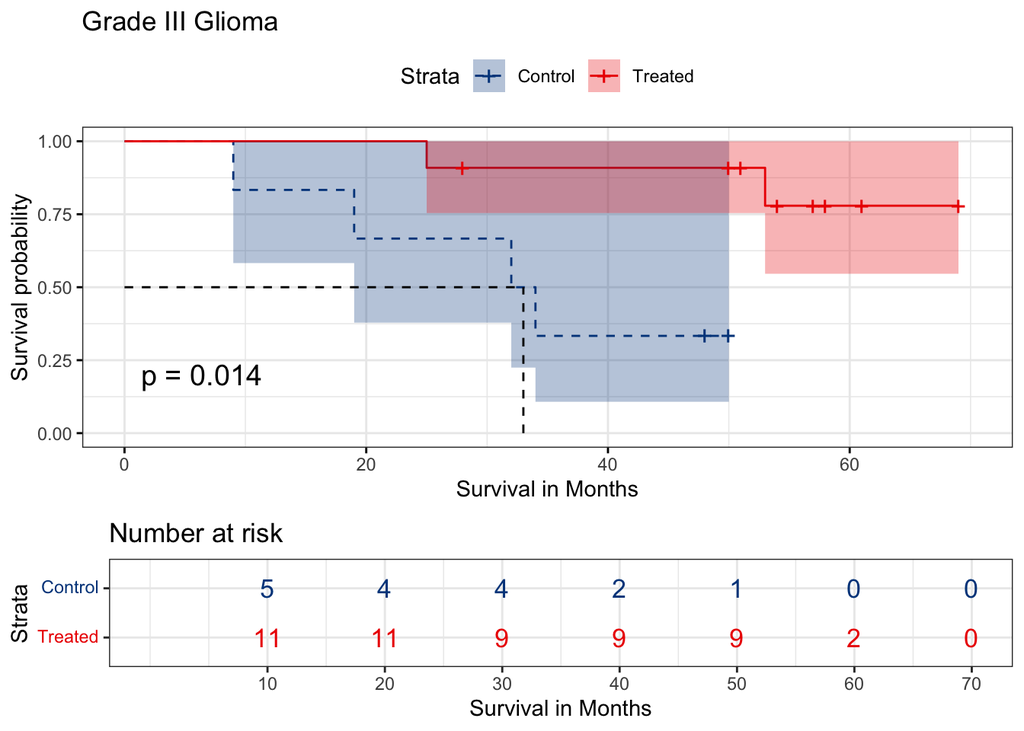

```r
# ggplot
ggsurvplot(
  survfit(Surv(time, event) ~ group, data = g3),
  data = g3,
  size = 0.5,                      # change line size
  linetype = c("dashed", "solid"), # different line type
  palette = "lancet",              # color red, blue or custom palettes lancet
  title   = "Grade III Glioma",    # plot main title
  xlab = "Survival in Months",     # customize X axis label.
  conf.int = TRUE,                 # Add confidence interval
  pval = TRUE,                     # Add p-value from log-rank test
  risk.table = TRUE,               # Add risk table
  risk.table.col = "strata",       # Risk table color by groups
  legend.labs = c("Control","Treated"),# Change legend labels
  risk.table.height = 0.30,        # Useful to change when you have multiple groups
  surv.median.line = "hv",         # add the median survival pointer.
  ggtheme = theme_bw()             # Change ggplot2 theme
)
```

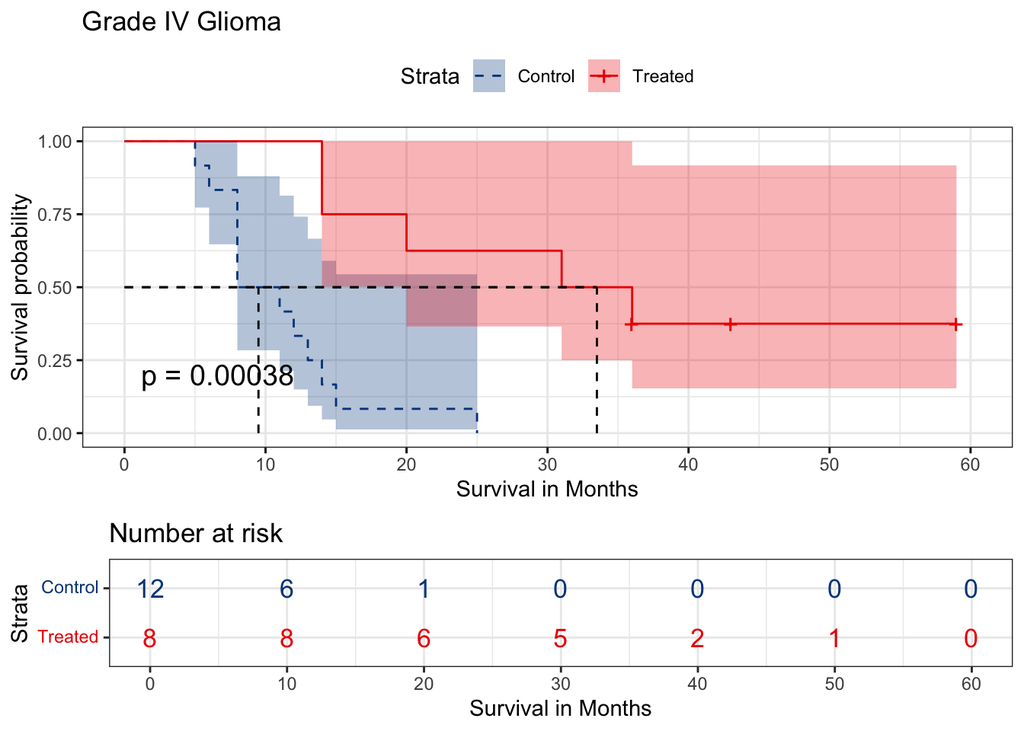

```r
# Other survival plots with ggplot
ggsurvplot(
survfit(Surv(time, event) ~ group, data = g4),
data = g4,
size = 0.5,                  # change line size
linetype = c("dashed", "solid"), # different line type
palette = "lancet",          # color red, blue or custom palettes lancet
title   = "Grade IV Glioma", # plot main title
xlab = "Survival in Months", # customize X axis label.
conf.int = TRUE,             # Add confidence interval
pval = TRUE,                 # Add p-value from log-rank test
risk.table = TRUE,           # Add risk table
risk.table.col = "strata",   # Risk table color by groups
legend.labs = c("Control","Treated"),    # Change legend labels
risk.table.height = 0.30,    # Useful to change when you have multiple groups
surv.median.line = "hv",     # add the median survival pointer.
ggtheme = theme_bw()         # Change ggplot2 theme
)
```

# The German Breast Cancer Study

To study the effects of hormonal treatment with Tamoxifen in women suffering from node-positive breast cancer in a randomized clinical trial. We will use the GBSG2 data from the TH data package. Data from this trial, non-randomized patients from the German Breast Cancer Study Group 2 (GBSG2). The complete data of seven prognostic factors of 686 women are used for prognostic modeling. The hypothetical prognostic factors are age, menopausal status, tumor size, tumor grade, number of positive lymph nodes, progesterone receptor, estrogen receptor, and if hormonal therapy was applied.  
The German Breast Cancer Study Group (GBSG2) dataset studies the effects of hormone treatment on recurrence-free survival time. The event of interest is the recurrence of cancer time:  
horTh: hormonal therapy, a factor at two levels (yes and no).  
age: age of the patients in years.  
menostat: menopausal status, a factor at two levels pre (premenopausal) and post (postmenopausal).  
tsize: tumor size (in mm).  
tgrade: tumor grade, a ordered factor at levels I < II < III.  
pnodes: number of positive nodes.  
progrec: progesterone receptor (in fmol).  
estrec: estrogen receptor (in fmol).  
time: recurrence free survival time (in days).  
cens: censoring indicator (0- censored, 1- event).

```r
data("GBSG2", package = "TH.data")

head(GBSG2)
```

```
  horTh age menostat tsize tgrade pnodes progrec estrec time cens
1    no  70     Post    21     II      3      48     66 1814    1
2   yes  56     Post    12     II      7      61     77 2018    1
3   yes  58     Post    35     II      9      52    271  712    1
4   yes  59     Post    17     II      4      60     29 1807    1
5    no  73     Post    35     II      1      26     65  772    1
6    no  32      Pre    57    III     24       0     13  448    1
```

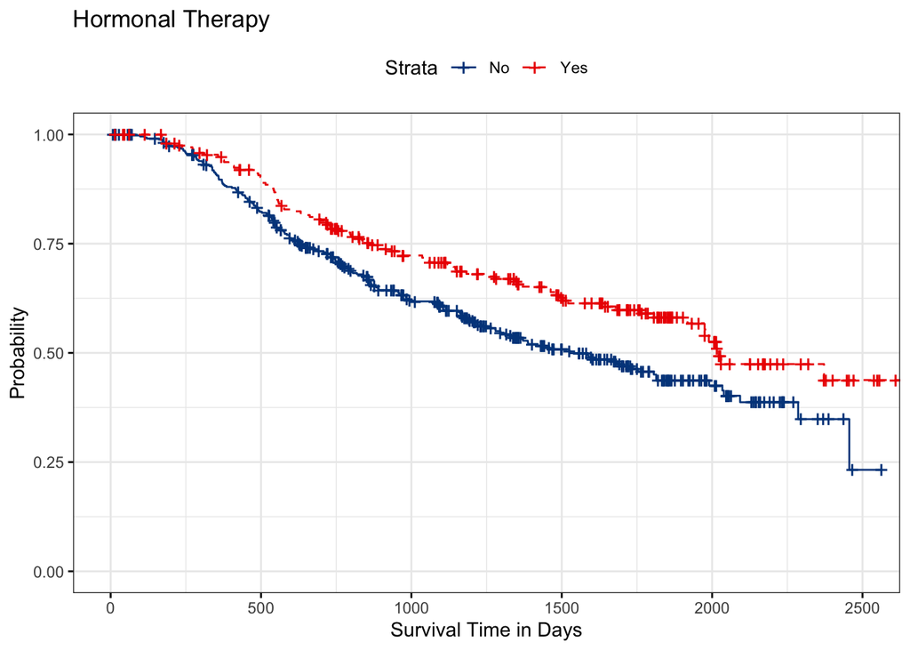

```r
ggsurvplot(
  survfit(Surv(time, cens) ~ horTh, data = GBSG2),
  data = GBSG2,
  size = 0.5,                     # change line size
  linetype = c("solid","dashed"), # different line type
  palette = "lancet",             # color palette
  title   = "Hormonal Therapy",   # plot main title
  xlab = "Survival Time in Days", # customize X axis label.
  ylab = "Probability",           # customize Y axis label
  ylim = c(0.0, 1.0),             # customize Y limits
  conf.int = FALSE,            # Add confidence interval
  pval = FALSE,               # Add p-value from log-rank test
  risk.table = FALSE,         # Add risk table
  risk.table.col = "strata",  # Risk table color by groups
  surv.median.line = "none",
  legend.labs = c("No","Yes"),
  risk.table.height = 0.25,   # Useful to change when you have multiple groups
  ggtheme = theme_bw()        # Change ggplot2 theme
  )
```

```r
GBSG2_coxph <- coxph(Surv(time, cens) ~ ., data = GBSG2)
summary(GBSG2_coxph)
```

```
Call:
coxph(formula = Surv(time, cens) ~ ., data = GBSG2)

  n= 686, number of events= 299

                   coef  exp(coef)   se(coef)      z Pr(>|z|)
horThyes     -0.3462784  0.7073155  0.1290747 -2.683 0.007301 **
age          -0.0094592  0.9905854  0.0093006 -1.017 0.309126
menostatPost  0.2584448  1.2949147  0.1834765  1.409 0.158954
tsize         0.0077961  1.0078266  0.0039390  1.979 0.047794 *
tgrade.L      0.5512988  1.7355056  0.1898441  2.904 0.003685 **
tgrade.Q     -0.2010905  0.8178384  0.1219654 -1.649 0.099199 .
pnodes        0.0487886  1.0499984  0.0074471  6.551  5.7e-11 ***
progrec      -0.0022172  0.9977852  0.0005735 -3.866 0.000111 ***
estrec        0.0001973  1.0001973  0.0004504  0.438 0.661307
---
Signif. codes:  0 '***' 0.001 '**' 0.01 '*' 0.05 '.' 0.1 ' ' 1

             exp(coef) exp(-coef) lower .95 upper .95
horThyes        0.7073     1.4138    0.5492    0.9109
age             0.9906     1.0095    0.9727    1.0088
menostatPost    1.2949     0.7723    0.9038    1.8553
tsize           1.0078     0.9922    1.0001    1.0156
tgrade.L        1.7355     0.5762    1.1963    2.5178
tgrade.Q        0.8178     1.2227    0.6439    1.0387
pnodes          1.0500     0.9524    1.0348    1.0654
progrec         0.9978     1.0022    0.9967    0.9989
estrec          1.0002     0.9998    0.9993    1.0011

Concordance= 0.692  (se = 0.015 )
Likelihood ratio test= 104.8  on 9 df,   p=<2e-16
Wald test            = 114.8  on 9 df,   p=<2e-16
Score (logrank) test = 120.7  on 9 df,   p=<2e-16
```

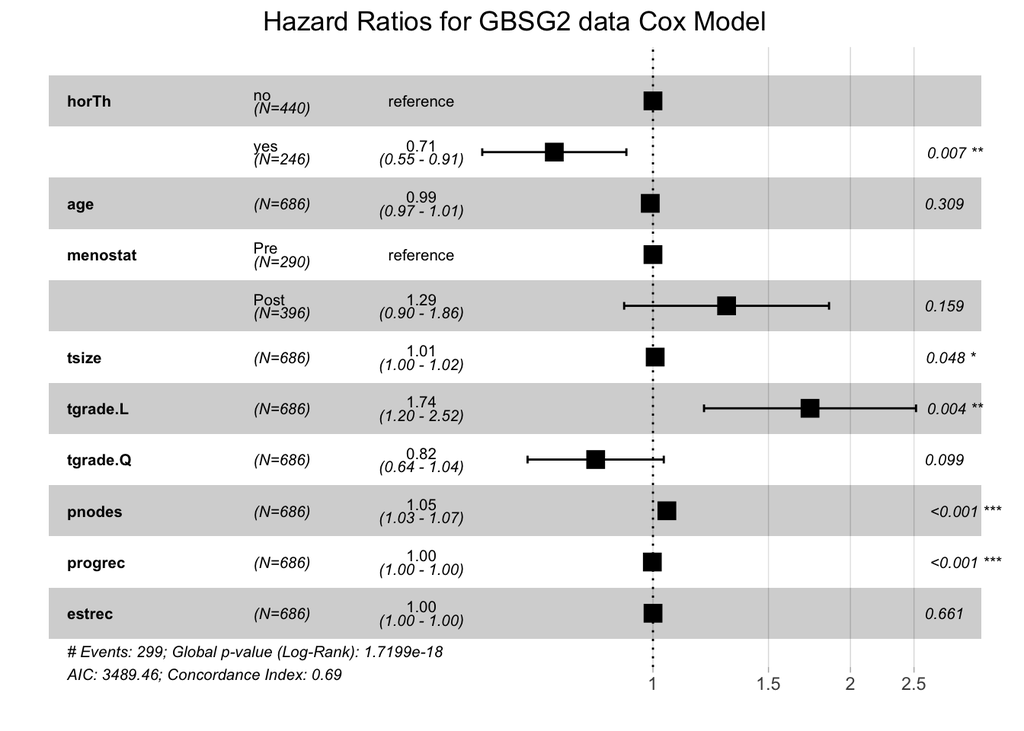

```r
ggforest(GBSG2_coxph, data = GBSG2, main = "Hazard Ratios for GBSG2 data Cox Model")
```

```r
#
ci <- confint(GBSG2_coxph)
exp(cbind(coef(GBSG2_coxph), ci))["horThyes",]
```

```
              2.5 %    97.5 %
0.7073155 0.5492178 0.9109233
```

```r
(GBSG2_zph <- cox.zph(GBSG2_coxph))
```

```
          chisq df      p
horTh     0.239  1 0.6253
age      10.438  1 0.0012
menostat  5.406  1 0.0201
tsize     0.191  1 0.6620
tgrade   10.712  2 0.0047
pnodes    0.808  1 0.3688
progrec   4.386  1 0.0362
estrec    5.893  1 0.0152
GLOBAL   24.421  9 0.0037
```

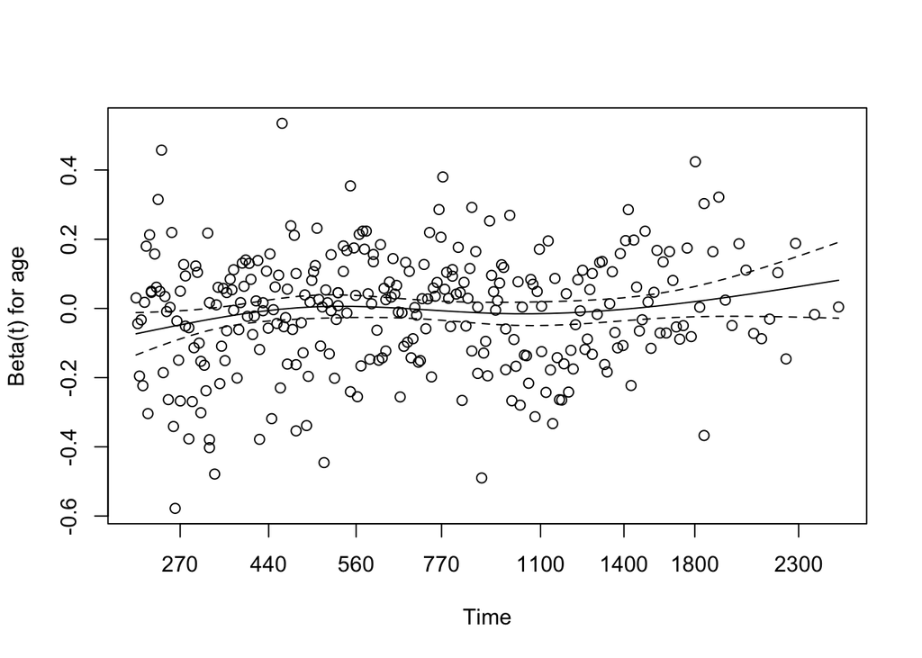

```r
# layout(matrix(1:4, ncol=2))
plot(GBSG2_zph, var = "age")
```

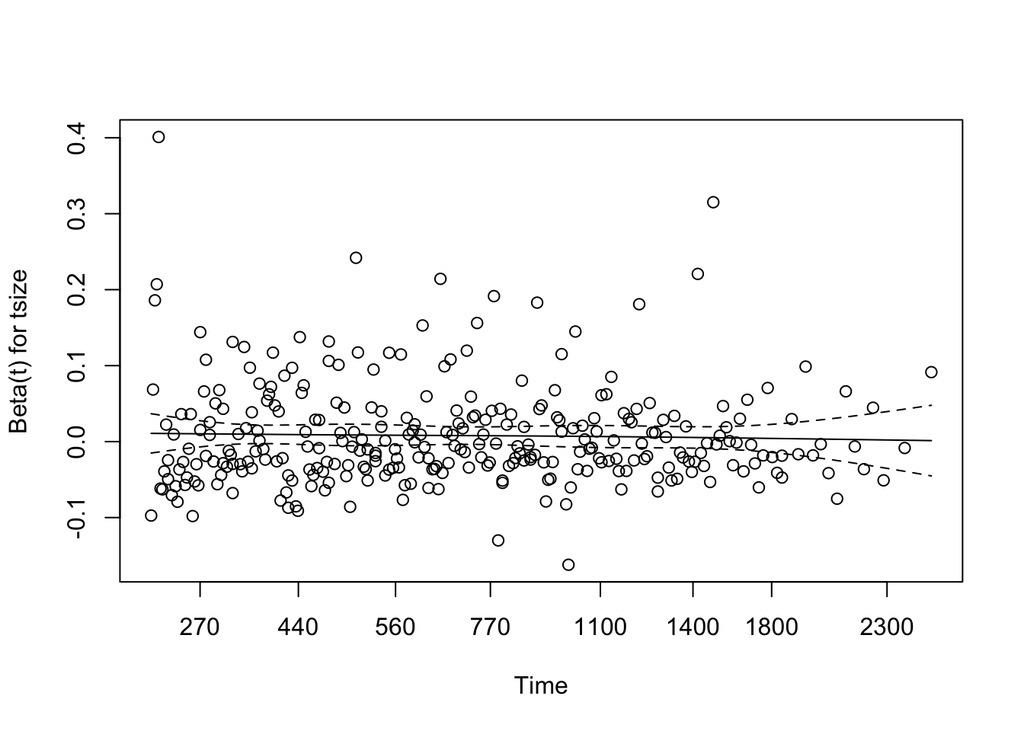

```r
plot(GBSG2_zph, var = "tsize")
```

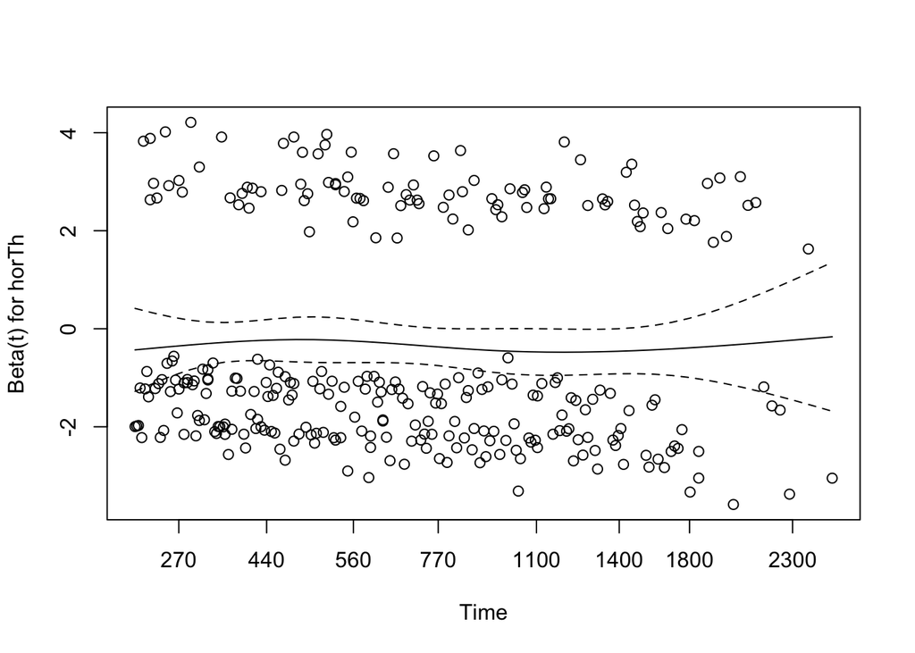

```r
plot(GBSG2_zph, var = "horTh")
```

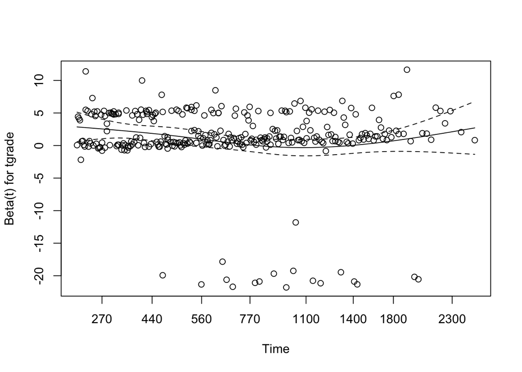

```r
plot(GBSG2_zph, var = "tgrade")
```

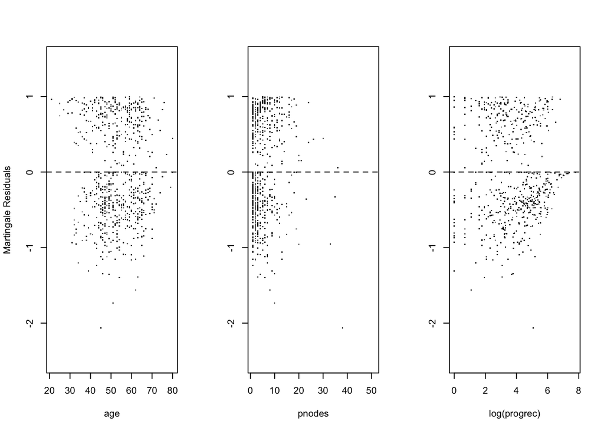

```r
# Martingale residuals are estimated by the residuals function
layout(matrix(1:3, ncol = 3))
res <- residuals(GBSG2_coxph)
plot(res ~ age, data = GBSG2, ylim = c(-2.5, 1.5), pch = ".", ylab = "Martingale Residuals")
abline(h = 0, lty = 2)
plot(res ~ pnodes, data = GBSG2, ylim = c(-2.5, 1.5), pch = ".", ylab = "")
abline(h = 0, lty = 2)
plot(res ~ log(progrec), data = GBSG2, ylim = c(-2.5, 1.5), pch = ".", ylab = "")
abline(h = 0, lty = 2)
```

In R tree-structure regression models are applicable to censored responses in survival analysis. The ctree function from package `partykit`. In the tree-structure regression the most important variable is the `pnodes`, number of positive lymph nodes, corresponding to the p-value associated with the variable in the Cox regression.

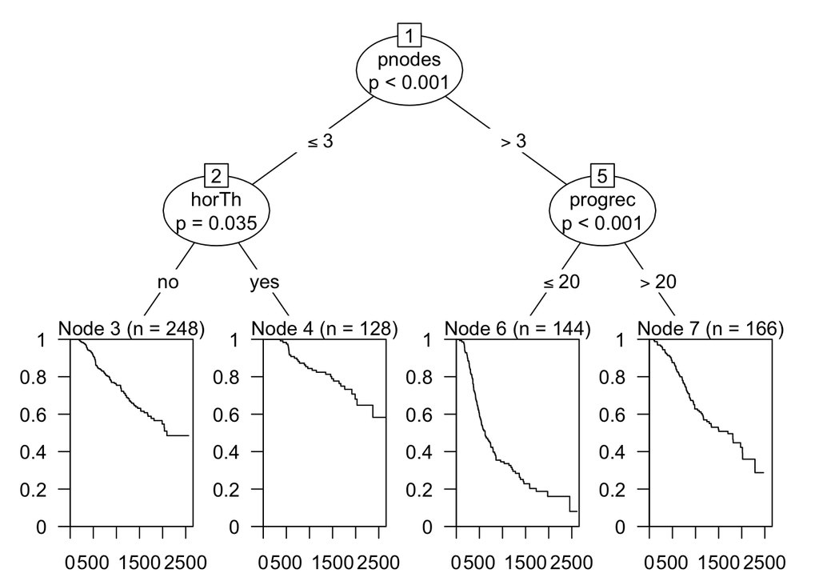

```r
GBSG2_ctree <- ctree(Surv(time, cens) ~ ., data = GBSG2)
plot(GBSG2_ctree)
```